# ckme project

Import dataset

```r
data <- read.csv("/Users/zafrinasomani/Desktop/CKME 136/mental-health-in-tech-2016.csv", header = T, na.strings = c("", "NA"))
clean <- data
```

Inspect dataset

```r
head(clean)
```

```
##   Are.you.self.employed.
## 1                      0
## 2                      0
## 3                      0
## 4                      1
## 5                      0
## 6                      0
##   How.many.employees.does.your.company.or.organization.have.
## 1                                                     26-100
## 2                                                       6-25
## 3                                                       6-25
## 4                                                       <NA>
## 5                                                       6-25
## 6                                             More than 1000
##   Is.your.employer.primarily.a.tech.company.organization.
```

[output cut: 405 more lines]

```r
#tail(clean)
summary(clean)
```

```
##  Are.you.self.employed.
##  Min.   :0.0000
##  1st Qu.:0.0000
##  Median :0.0000
##  Mean   :0.2003
##  3rd Qu.:0.0000
##  Max.   :1.0000
##
##  How.many.employees.does.your.company.or.organization.have.
##  1-5           : 60
##  100-500       :248
##  26-100        :292
##  500-1000      : 80
##  6-25          :210
##  More than 1000:256
##  NA's          :287
##  Is.your.employer.primarily.a.tech.company.organization.
##  Min.   :0.0000
##  1st Qu.:1.0000
##  Median :1.0000
##  Mean   :0.7705
##  3rd Qu.:1.0000
##  Max.   :1.0000
##  NA's   :287
##  Is.your.primary.role.within.your.company.related.to.tech.IT.
##  Min.   :0.000
##  1st Qu.:1.000
##  Median :1.000
##  Mean   :0.943
##  3rd Qu.:1.000
##  Max.   :1.000
##  NA's   :1170
##  Does.your.employer.provide.mental.health.benefits.as.part.of.healthcare.coverage.
##  I don't know                   :319
##  No                             :213
##  Not eligible for coverage / N/A: 83
##  Yes                            :531
##  NA's                           :287
##
##
```

[output cut: 433 more lines]

```
##  Back-end Developer                    :263
##  Front-end Developer                   :125
##  Other                                 :112
##  Supervisor/Team Lead                  : 68
##  Back-end Developer|Front-end Developer: 61
##  DevOps/SysAdmin                       : 54
##  (Other)                               :750
##  Do.you.work.remotely.
##  Always   :343
##  Never    :333
##  Sometimes:757
##
##
##
##
```

```r
str(clean)
```

```
## 'data.frame':    1433 obs. of  63 variables:
##  $ Are.you.self.employed.                                                                                                                                                          : int  0 0 0 1 0 0 0 0 0 1 ...
##  $ How.many.employees.does.your.company.or.organization.have.                                                                                                                      : Factor w/ 6 levels "1-5","100-500",..: 3 5 5 NA 5 6 3 6 3 NA ...
##  $ Is.your.employer.primarily.a.tech.company.organization.                                                                                                                         : int  1 1 1 NA 0 1 1 1 0 NA ...
##  $ Is.your.primary.role.within.your.company.related.to.tech.IT.                                                                                                                    : int  NA NA NA NA 1 NA NA NA 1 NA ...
##  $ Does.your.employer.provide.mental.health.benefits.as.part.of.healthcare.coverage.                                                                                               : Factor w/ 4 levels "I don't know",..: 3 2 2 NA 4 4 1 4 1 NA ...
##  $ Do.you.know.the.options.for.mental.health.care.available.under.your.employer.provided.coverage.                                                                                 : Factor w/ 4 levels "I am not sure",..: 2 4 2 NA 4 1 3 4 3 NA ...
##  $ Has.your.employer.ever.formally.discussed.mental.health..for.example..as.part.of.a.wellness.campaign.or.other.official.communication..                                          : Factor w/ 3 levels "I don't know",..: 2 3 2 NA 2 2 2 2 2 NA ...
##  $ Does.your.employer.offer.resources.to.learn.more.about.mental.health.concerns.and.options.for.seeking.help.                                                                     : Factor w/ 3 levels "I don't know",..: 2 3 2 NA 2 3 2 3 2 NA ...
##  $ Is.your.anonymity.protected.if.you.choose.to.take.advantage.of.mental.health.or.substance.abuse.treatment.resources.provided.by.your.employer.                                  : Factor w/ 3 levels "I don't know",..: 1 3 1 NA 2 3 1 3 1 NA ...
##  $ If.a.mental.health.issue.prompted.you.to.request.a.medical.leave.from.work..asking.for.that.leave.would.be.                                                                     : Factor w/ 6 levels "I don't know",..: 6 4 2 NA 2 4 4 6 5 NA ...
##  $ Do.you.think.that.discussing.a.mental.health.disorder.with.your.employer.would.have.negative.consequences.                                                                      : Factor w/ 3 levels "Maybe","No","Yes": 2 2 1 NA 3 3 2 2 3 NA ...
##  $ Do.you.think.that.discussing.a.physical.health.issue.with.your.employer.would.have.negative.consequences.                                                                       : Factor w/ 3 levels "Maybe","No","Yes": 2 2 2 NA 1 3 2 2 3 NA ...
##  $ Would.you.feel.comfortable.discussing.a.mental.health.disorder.with.your.coworkers.                                                                                             : Factor w/ 3 levels "Maybe","No","Yes": 1 1 1 NA 1 1 1 1 3 NA ...
##  $ Would.you.feel.comfortable.discussing.a.mental.health.disorder.with.your.direct.supervisor.s..                                                                                  : Factor w/ 3 levels "Maybe","No","Yes": 3 3 1 NA 2 3 3 3 1 NA ...
```

[output cut: 49 more lines]

```r
dim(clean)
```

```
## [1] 1433   63
```

```r
head(names(clean))
```

```
## [1] "Are.you.self.employed."
## [2] "How.many.employees.does.your.company.or.organization.have."
## [3] "Is.your.employer.primarily.a.tech.company.organization."
## [4] "Is.your.primary.role.within.your.company.related.to.tech.IT."
## [5] "Does.your.employer.provide.mental.health.benefits.as.part.of.healthcare.coverage."
## [6] "Do.you.know.the.options.for.mental.health.care.available.under.your.employer.provided.coverage."
```

Assign correct data types

```r
clean$Are.you.self.employed. <- as.factor(clean$Are.you.self.employed.)
clean$Is.your.employer.primarily.a.tech.company.organization. <- as.factor(clean$Is.your.employer.primarily.a.tech.company.organization.)
clean$Is.your.primary.role.within.your.company.related.to.tech.IT. <- as.factor(clean$Is.your.primary.role.within.your.company.related.to.tech.IT.)
clean$Do.you.have.medical.coverage..private.insurance.or.state.provided..which.includes.treatment.of..mental.health.issues. <- as.factor(clean$Do.you.have.medical.coverage..private.insurance.or.state.provided..which.includes.treatment.of..mental.health.issues.)
clean$Do.you.have.previous.employers. <- as.factor(clean$Do.you.have.previous.employers.)
clean$Have.you.ever.sought.treatment.for.a.mental.health.issue.from.a.mental.health.professional. <- as.factor(clean$Have.you.ever.sought.treatment.for.a.mental.health.issue.from.a.mental.health.professional.)
```

Removed individuals who are self-employed and who do not work in an IT company or in the tech department

```r
clean <- subset(clean, clean$Are.you.self.employed. == 0)
clean <- subset(clean, clean$Is.your.primary.role.within.your.company.related.to.tech.IT. == 1 | clean$Is.your.employer.primarily.a.tech.company.organization. == 1)
```

Remove questions questions that were asked only to self-employed individuals.

```r
clean$Do.you.have.medical.coverage..private.insurance.or.state.provided..which.includes.treatment.of..mental.health.issues. <- NULL
clean$Do.you.know.local.or.online.resources.to.seek.help.for.a.mental.health.disorder. <- NULL
clean$If.you.have.been.diagnosed.or.treated.for.a.mental.health.disorder..do.you.ever.reveal.this.to.clients.or.business.contacts. <- NULL
clean$If.you.have.revealed.a.mental.health.issue.to.a.client.or.business.contact..do.you.believe.this.has.impacted.you.negatively. <- NULL
clean$If.you.have.been.diagnosed.or.treated.for.a.mental.health.disorder..do.you.ever.reveal.this.to.coworkers.or.employees. <- NULL
clean$If.you.have.revealed.a.mental.health.issue.to.a.coworker.or.employee..do.you.believe.this.has.impacted.you.negatively. <- NULL
clean$Do.you.believe.your.productivity.is.ever.affected.by.a.mental.health.issue. <- NULL
clean$If.yes..what.percentage.of.your.work.time..time.performing.primary.or.secondary.job.functions..is.affected.by.a.mental.health.issue. <- NULL
```

Remove outliers in age which appear to be data entry errors:

```r
clean <- subset(clean, !clean$What.is.your.age. == 323)
clean <- subset(clean, !clean$What.is.your.age. == 3)
clean <- subset(clean, !clean$What.is.your.age. == 99)
```

Distribution of Age

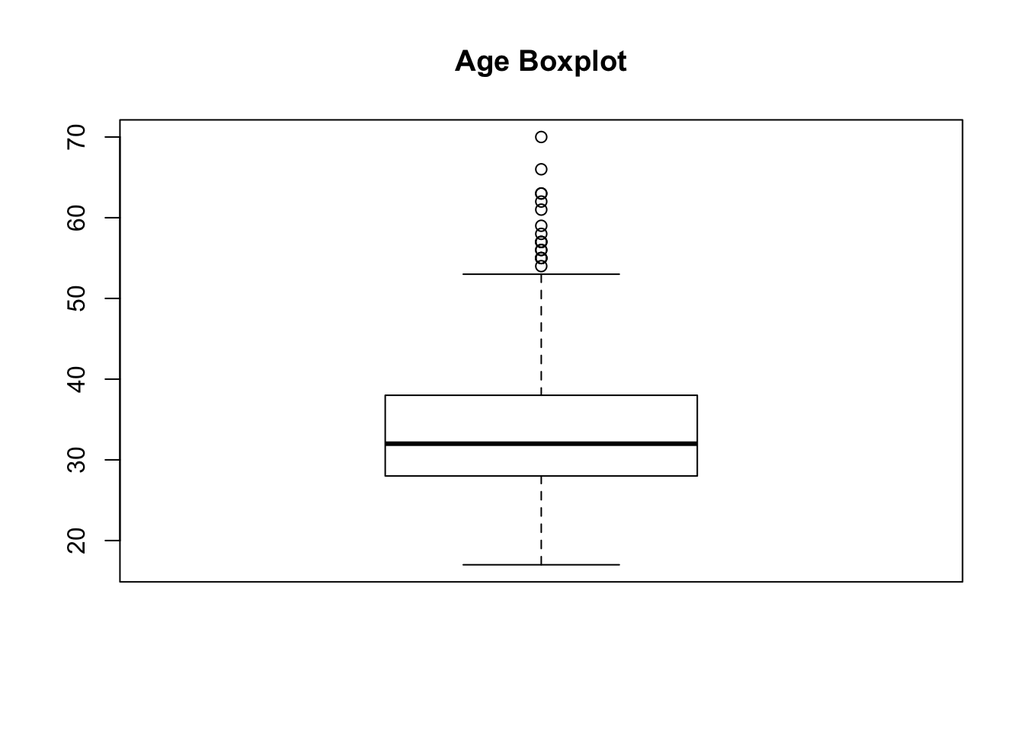

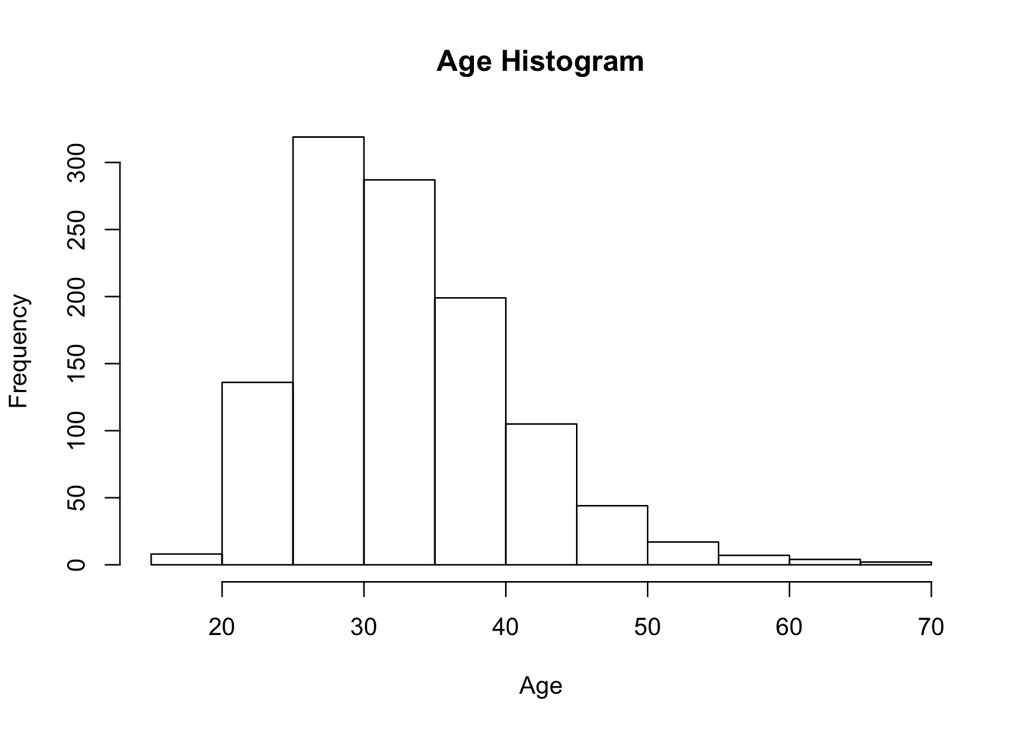

Rename columns - shorten column names

```r
names(clean)[names(clean) == "Are.you.self.employed."] <- c("self_employed")
names(clean)[names(clean) == "How.many.employees.does.your.company.or.organization.have."] <- c("no_of_employees")
names(clean)[names(clean) == "Is.your.employer.primarily.a.tech.company.organization."] <- c("tech_company")
names(clean)[names(clean) == "Is.your.primary.role.within.your.company.related.to.tech.IT."] <- c("tech_role")
names(clean)[names(clean) == "Does.your.employer.provide.mental.health.benefits.as.part.of.healthcare.coverage."] <- c("mental_health_benefits")
names(clean)[names(clean) == "Do.you.know.the.options.for.mental.health.care.available.under.your.employer.provided.coverage."] <- c("options_mental_health")
names(clean)[names(clean) == "Has.your.employer.ever.formally.discussed.mental.health..for.example..as.part.of.a.wellness.campaign.or.other.official.communication.."] <- c("wellness_campaign")
names(clean)[names(clean) == "Does.your.employer.offer.resources.to.learn.more.about.mental.health.concerns.and.options.for.seeking.help."] <- c("mh_resources")
names(clean)[names(clean) == "Is.your.anonymity.protected.if.you.choose.to.take.advantage.of.mental.health.or.substance.abuse.treatment.resources.provided.by.your.employer."] <- c("anonymity")
names(clean)[names(clean) == "If.a.mental.health.issue.prompted.you.to.request.a.medical.leave.from.work..asking.for.that.leave.would.be."] <- c("mh_leave_request")
names(clean)[names(clean) == "Do.you.think.that.discussing.a.mental.health.disorder.with.your.employer.would.have.negative.consequences."] <- c("mh_discuss_neg_cons")
names(clean)[names(clean) == "Do.you.think.that.discussing.a.physical.health.issue.with.your.employer.would.have.negative.consequences."] <- c("ph_discuss_neg_cons")
names(clean)[names(clean) == "Would.you.feel.comfortable.discussing.a.mental.health.disorder.with.your.coworkers."] <- c("mh_discuss_coworker")
names(clean)[names(clean) == "Would.you.feel.comfortable.discussing.a.mental.health.disorder.with.your.direct.supervisor.s.."] <- c("mh_discuss_supervisor")
names(clean)[names(clean) == "Do.you.feel.that.your.employer.takes.mental.health.as.seriously.as.physical.health."] <- c("mh_serious_ph")
names(clean)[names(clean) == "Have.you.heard.of.or.observed.negative.consequences.for.co.workers.who.have.been.open.about.mental.health.issues.in.your.workplace."] <- c("observe_negcons_mh")
names(clean)[names(clean) == "Do.you.have.previous.employers."] <- c("previous_employer")
names(clean)[names(clean) == "Have.your.previous.employers.provided.mental.health.benefits."] <- c("pe_mh_benefits")
names(clean)[names(clean) == "Were.you.aware.of.the.options.for.mental.health.care.provided.by.your.previous.employers."] <- c("pe_mh_options")
names(clean)[names(clean) == "Did.your.previous.employers.ever.formally.discuss.mental.health..as.part.of.a.wellness.campaign.or.other.official.communication.."] <- c("pe_wellness_campaign")
names(clean)[names(clean) == "Did.your.previous.employers.provide.resources.to.learn.more.about.mental.health.issues.and.how.to.seek.help."] <- c("pe_mh_resources")
names(clean)[names(clean) == "Was.your.anonymity.protected.if.you.chose.to.take.advantage.of.mental.health.or.substance.abuse.treatment.resources.with.previous.employers."] <- c("pe_anonymity")
names(clean)[names(clean) == "Do.you.think.that.discussing.a.mental.health.disorder.with.previous.employers.would.have.negative.consequences."] <- c("pe_mh_discuss_negcons")
names(clean)[names(clean) == "Do.you.think.that.discussing.a.physical.health.issue.with.previous.employers.would.have.negative.consequences."] <- c("pe_ph_discuss_negcons")
names(clean)[names(clean) == "Would.you.have.been.willing.to.discuss.a.mental.health.issue.with.your.previous.co.workers."] <- c("pe_mh_discuss_coworker")
names(clean)[names(clean) == "Would.you.have.been.willing.to.discuss.a.mental.health.issue.with.your.direct.supervisor.s.."] <- c("pe_mh_discuss_supervisor")
names(clean)[names(clean) == "Did.you.feel.that.your.previous.employers.took.mental.health.as.seriously.as.physical.health."] <- c("pe_mh_serious_ph")
names(clean)[names(clean) == "Did.you.hear.of.or.observe.negative.consequences.for.co.workers.with.mental.health.issues.in.your.previous.workplaces."] <- c("pe_observe_negcons_mh")
names(clean)[names(clean) == "Would.you.be.willing.to.bring.up.a.physical.health.issue.with.a.potential.employer.in.an.interview."] <- c("ph_interview")
names(clean)[names(clean) == "Why.or.why.not."] <- c("ph_interview_why")
names(clean)[names(clean) == "Would.you.bring.up.a.mental.health.issue.with.a.potential.employer.in.an.interview."] <- c("mh_interview")
names(clean)[names(clean) == "Why.or.why.not..1"] <- c("mh_interview_why")
names(clean)[names(clean) == "Do.you.feel.that.being.identified.as.a.person.with.a.mental.health.issue.would.hurt.your.career."] <- c("id_mh_hurt_career")
names(clean)[names(clean) == "Do.you.think.that.team.members.co.workers.would.view.you.more.negatively.if.they.knew.you.suffered.from.a.mental.health.issue."] <- c("team_neg_view_mh")
names(clean)[names(clean) == "How.willing.would.you.be.to.share.with.friends.and.family.that.you.have.a.mental.illness."] <- c("friends_family")
names(clean)[names(clean) == "Have.you.observed.or.experienced.an.unsupportive.or.badly.handled.response.to.a.mental.health.issue.in.your.current.or.previous.workplace."] <- c("unsupportive_response_mh")
names(clean)[names(clean) == "Have.your.observations.of.how.another.individual.who.discussed.a.mental.health.disorder.made.you.less.likely.to.reveal.a.mental.health.issue.yourself.in.your.current.workplace."] <- c("obs_impact")
names(clean)[names(clean) == "Do.you.have.a.family.history.of.mental.illness."] <- c("mh_family_history")
names(clean)[names(clean) == "Have.you.had.a.mental.health.disorder.in.the.past."] <- c("mh_past")
names(clean)[names(clean) == "Do.you.currently.have.a.mental.health.disorder."] <- c("mh_current")
names(clean)[names(clean) == "If.yes..what.condition.s..have.you.been.diagnosed.with."] <- c("current_diagnosis")
names(clean)[names(clean) == "If.maybe..what.condition.s..do.you.believe.you.have."] <- c("condition_undiagnosed")
names(clean)[names(clean) == "Have.you.been.diagnosed.with.a.mental.health.condition.by.a.medical.professional."] <- c("diagnosed_medpro")
names(clean)[names(clean) == "If.so..what.condition.s..were.you.diagnosed.with."] <- c("condition_diagnosed_medpro")
names(clean)[names(clean) == "Have.you.ever.sought.treatment.for.a.mental.health.issue.from.a.mental.health.professional."] <- c("sought_treatment")
names(clean)[names(clean) == "If.you.have.a.mental.health.issue..do.you.feel.that.it.interferes.with.your.work.when.being.treated.effectively."] <- c("mhi_work_treated_effectively")
names(clean)[names(clean) == "If.you.have.a.mental.health.issue..do.you.feel.that.it.interferes.with.your.work.when.NOT.being.treated.effectively."] <- c("mhi_work_not_treated_effectively")
names(clean)[names(clean) == "What.is.your.age."] <- c("age")
names(clean)[names(clean) == "What.is.your.gender."] <- c("gender")
names(clean)[names(clean) == "What.country.do.you.live.in."] <- c("home_country")
names(clean)[names(clean) == "What.US.state.or.territory.do.you.live.in."] <- c("home_state")
names(clean)[names(clean) == "What.country.do.you.work.in."] <- c("work_country")
names(clean)[names(clean) == "What.US.state.or.territory.do.you.work.in."] <- c("work_state")
names(clean)[names(clean) == "Which.of.the.following.best.describes.your.work.position."] <- c("work_position")
names(clean)[names(clean) == "Do.you.work.remotely."] <- c("work_remotely")
summary(clean)
```

```
##  self_employed       no_of_employees tech_company tech_role
##  0:1128        1-5           : 59    0:248        0   :  0
##  1:   0        100-500       :244    1:880        1   :248
##                26-100        :291                 NA's:880
##                500-1000      : 79
##                6-25          :205
##                More than 1000:250
##
##                      mental_health_benefits   options_mental_health
##  I don't know                   :316        I am not sure:348
##  No                             :210        N/A          :133
##  Not eligible for coverage / N/A: 81        No           :347
##  Yes                            :521        Yes          :300
##
##
##
##     wellness_campaign       mh_resources        anonymity
##  I don't know:101     I don't know:316   I don't know:734
##  No          :805     No          :523   No          : 83
##  Yes         :222     Yes         :289   Yes         :311
##
##
##
##
##                    mh_leave_request mh_discuss_neg_cons ph_discuss_neg_cons
##  I don't know              :148     Maybe:481           Maybe:260
##  Neither easy nor difficult:176     No   :434           No   :828
##  Somewhat difficult        :192     Yes  :213           Yes  : 40
##  Somewhat easy             :277
##  Very difficult            :116
##  Very easy                 :219
##
##  mh_discuss_coworker mh_discuss_supervisor      mh_serious_ph
##  Maybe:472           Maybe:377             I don't know:485
##  No   :386           No   :329             No          :298
##  Yes  :270           Yes  :422             Yes         :345
##
##
##
##
```

[output cut: 137 more lines]

```
##  United States of America:693   California:106   United States of America:700
##  United Kingdom          :134   Illinois  : 47   United Kingdom          :133
##  Canada                  : 62   Michigan  : 42   Canada                  : 60
##  Germany                 : 43   Minnesota : 37   Germany                 : 43
##  Netherlands             : 31   Texas     : 36   Netherlands             : 31
##  Australia               : 26   (Other)   :425   Australia               : 26
##  (Other)                 :139   NA's      :435   (Other)                 :135
##       work_state                                 work_position   work_remotely
##  California:116   Back-end Developer                    :236   Always   :217
##  Illinois  : 48   Front-end Developer                   :115   Never    :311
##  Michigan  : 41   Other                                 : 92   Sometimes:600
##  New York  : 38   Back-end Developer|Front-end Developer: 58
##  Minnesota : 37   Supervisor/Team Lead                  : 58
##  (Other)   :420   DevOps/SysAdmin                       : 48
##  NA's      :428   (Other)                               :521
```

Clean gender variable

```r
clean$gender <- as.character(clean$gender)
clean$gender[clean$gender == "Agender"] <- c("other")
clean$gender[clean$gender == "Androgynous"] <- c("other")
clean$gender[clean$gender == "Bigender"] <- c("other")
clean$gender[clean$gender == "Cis female"] <- c("female")
clean$gender[clean$gender == "cis male"] <- c("male")
clean$gender[clean$gender == "Cis male"] <- c("male")
clean$gender[clean$gender == "Cis Male"] <- c("male")
clean$gender[clean$gender == "cis man"] <- c("male")
clean$gender[clean$gender == "Cis-woman"] <- c("female")
clean$gender[clean$gender == "cisdude"] <- c("male")
clean$gender[clean$gender == "Cisgender Female"] <- c("female")
clean$gender[clean$gender == "Dude"] <- c("male")
clean$gender[clean$gender == "Enby"] <- c("other")
clean$gender[clean$gender == "f"] <- c("female")
clean$gender[clean$gender == "F"] <- c("female")
clean$gender[clean$gender == "fem"] <- c("female")
clean$gender[clean$gender == "Female"] <- c("female")
clean$gender[clean$gender == "female "] <- c("female")
clean$gender[clean$gender == "Female "] <- c("female")
clean$gender[clean$gender == "Female (props for making this a freeform field, though)"] <- c("female")
clean$gender[clean$gender == "Female assigned at birth"] <- c("female")
clean$gender[clean$gender == "Female or Multi-Gender Femme"] <- c("female")
clean$gender[clean$gender == "female-bodied; no feelings about gender"] <- c("female")
clean$gender[clean$gender == "female/woman"] <- c("female")
clean$gender[clean$gender == "fm"] <- c("female")
clean$gender[clean$gender == "Genderfluid "] <- c("other")
clean$gender[clean$gender == "Genderfluid (born female)"] <- c("other")
clean$gender[clean$gender == "Genderflux demi-girl"] <- c("other")
clean$gender[clean$gender == "genderqueer"] <- c("other")
clean$gender[clean$gender == "Genderqueer"] <- c("other")
clean$gender[clean$gender == "genderqueer woman"] <- c("other")
clean$gender[clean$gender == "Human"] <- c("other")
clean$gender[clean$gender == "I identify as female."] <- c("female")
clean$gender[clean$gender == "m"] <- c("male")
clean$gender[clean$gender == "M"] <- c("male")
clean$gender[clean$gender == "mail"] <- c("male")
clean$gender[clean$gender == "male "] <- c("male")
clean$gender[clean$gender == "Male"] <- c("male")
clean$gender[clean$gender == "Male "] <- c("male")
clean$gender[clean$gender == "Male (cis)"] <- c("male")
clean$gender[clean$gender == "Male (trans, FtM)"] <- c("male")
clean$gender[clean$gender == "male 9:1 female, roughly"] <- c("other")
clean$gender[clean$gender == "Male."] <- c("male")
clean$gender[clean$gender == "Male/genderqueer"] <- c("other")
clean$gender[clean$gender == "man"] <- c("male")
clean$gender[clean$gender == "Man"] <- c("male")
clean$gender[clean$gender == "N/A"] <- c("other")
clean$gender[clean$gender == "nb masculine"] <- c("other")
clean$gender[clean$gender == "non-binary"] <- c("other")
clean$gender[clean$gender == "Nonbinary"] <- c("other")
clean$gender[clean$gender == "none of your business"] <- c("other")
clean$gender[clean$gender == "Other/Transfeminine"] <- c("other")
clean$gender[clean$gender == "Queer"] <- c("other")
clean$gender[clean$gender == "Sex is male"] <- c("male")
clean$gender[clean$gender == "Transgender woman"] <- c("other")
clean$gender[clean$gender == "Transitioned, M2F"] <- c("female")
clean$gender[clean$gender == "Woman"] <- c("female")
clean$gender[clean$gender == "Cis female "] <- c("female")
clean$gender[clean$gender == "Female assigned at birth "] <- c("female")
clean$gender[clean$gender == "Genderfluid"] <- c("other")
clean$gender[clean$gender == "woman"] <- c("female")
clean$gender[is.na(clean$gender)] <- c("other")
clean$gender <- as.factor(clean$gender)
summary(clean$gender)
```

```
## female   male  other
##    262    839     27
```

Create new dataframe with current diagnoses - will show individuals with multiple diagnoses and what the diagnoses are

```r
library(tidyr)
library(dplyr)
currentdiagnosis <- clean %>% separate(current_diagnosis, sep = '\\|', c("curdiag_1", "curdiag_2", "curdiag_3","curdiag_4","curdiag_5","curdiag_6","curdiag_7","curdiag_8"), fill = 'right')
currentdiagnosis %>% select(matches('curdiag_[1-8]')) %>% str()
```

```
## 'data.frame':    1128 obs. of  8 variables:
##  $ curdiag_1: chr  NA "Anxiety Disorder (Generalized, Social, Phobia, etc)" NA "Anxiety Disorder (Generalized, Social, Phobia, etc)" ...
##  $ curdiag_2: chr  NA "Mood Disorder (Depression, Bipolar Disorder, etc)" NA "Stress Response Syndromes" ...
##  $ curdiag_3: chr  NA NA NA NA ...
##  $ curdiag_4: chr  NA NA NA NA ...
##  $ curdiag_5: chr  NA NA NA NA ...
##  $ curdiag_6: chr  NA NA NA NA ...
##  $ curdiag_7: chr  NA NA NA NA ...
##  $ curdiag_8: chr  NA NA NA NA ...
```

```r
currentdiagnosis <- currentdiagnosis %>% select(matches("curdiag_[1-8]")) %>% mutate_each(funs = 'as.factor')
currentdiagnosis %>% select(matches("curdiag_[1-8]")) %>% str()
```

```
## 'data.frame':    1128 obs. of  8 variables:
##  $ curdiag_1: Factor w/ 17 levels "Addictive Disorder",..: NA 2 NA 2 2 NA 2 7 7 2 ...
##  $ curdiag_2: Factor w/ 15 levels "Addictive Disorder",..: NA 7 NA 14 14 NA 15 NA NA NA ...
##  $ curdiag_3: Factor w/ 12 levels "ADD (w/o Hyperactivity)",..: NA NA NA NA 12 NA NA NA NA NA ...
##  $ curdiag_4: Factor w/ 9 levels "Addictive Disorder",..: NA NA NA NA NA NA NA NA NA NA ...
##  $ curdiag_5: Factor w/ 5 levels "Addictive Disorder",..: NA NA NA NA NA NA NA NA NA NA ...
##  $ curdiag_6: Factor w/ 3 levels "Addictive Disorder",..: NA NA NA NA NA NA NA NA NA NA ...
##  $ curdiag_7: Factor w/ 1 level "Dissociative Disorder": NA NA NA NA NA NA NA NA NA NA ...
##  $ curdiag_8: Factor w/ 1 level "Substance Use Disorder": NA NA NA NA NA NA NA NA NA NA ...
```

```r
currentdiagnosis$na_count <- as.factor(apply(is.na(currentdiagnosis), MARGIN = 1, FUN = sum))
summary(currentdiagnosis)
```

```
##                                                     curdiag_1
##  Anxiety Disorder (Generalized, Social, Phobia, etc)     :263
##  Mood Disorder (Depression, Bipolar Disorder, etc)       :129
##  Attention Deficit Hyperactivity Disorder                : 18
##  Post-traumatic Stress Disorder                          :  8
##  Psychotic Disorder (Schizophrenia, Schizoaffective, etc):  4
##  (Other)                                                 : 16
##  NA's                                                    :690
##                                              curdiag_2
##  Mood Disorder (Depression, Bipolar Disorder, etc):192
##  Attention Deficit Hyperactivity Disorder         : 43
##  Obsessive-Compulsive Disorder                    :  9
##  Post-traumatic Stress Disorder                   :  9
##  Substance Use Disorder                           :  8
##  (Other)                                          : 27
##  NA's                                             :840
##                                     curdiag_3
##  Attention Deficit Hyperactivity Disorder:  31
##  Post-traumatic Stress Disorder          :  24
##  Obsessive-Compulsive Disorder           :  16
##  Eating Disorder (Anorexia, Bulimia, etc):  12
##  Stress Response Syndromes               :  11
##  (Other)                                 :  30
##  NA's                                    :1004
##                                                         curdiag_4
##  Addictive Disorder                                          :  10
##  Post-traumatic Stress Disorder                              :   8
##  Substance Use Disorder                                      :   7
##  Obsessive-Compulsive Disorder                               :   6
##  Personality Disorder (Borderline, Antisocial, Paranoid, etc):   5
##  (Other)                                                     :   7
##  NA's                                                        :1085
##                          curdiag_5                             curdiag_6
##  Addictive Disorder           :   2   Addictive Disorder            :   3
##  Autism                       :   1   Post-traumatic Stress Disorder:   1
##  Obsessive-Compulsive Disorder:   2   Stress Response Syndromes     :   1
##  Stress Response Syndromes    :   2   NA's                          :1123
##  Substance Use Disorder       :   4
##  NA's                         :1117
##
##                  curdiag_7                     curdiag_8       na_count
##  Dissociative Disorder:   1   Substance Use Disorder:   1   8      :690
##  NA's                 :1127   NA's                  :1127   6      :164
##                                                             7      :150
##                                                             5      : 81
##                                                             4      : 32
##                                                             3      :  6
##                                                             (Other):  5
```

Create new dataframe separating work positions, so each work position is in a new column

```r
clean$work_position <- as.factor(clean$work_position)
job <- clean %>% separate(work_position, sep = '\\|', c("wp_1", "wp_2", "wp_3", "wp_4", "wp_5", "wp_6", "wp_7", "wp_8", "wp_9", "wp_10"), fill = 'right')
job %>% select(matches('wp_[1-9]', 'wp_10')) %>% str()
```

```
## 'data.frame':    1128 obs. of  10 variables:
##  $ wp_1 : chr  "Back-end Developer" "Back-end Developer" "Back-end Developer" "Executive Leadership" ...
##  $ wp_2 : chr  NA "Front-end Developer" NA "Supervisor/Team Lead" ...
##  $ wp_3 : chr  NA NA NA "Dev Evangelist/Advocate" ...
##  $ wp_4 : chr  NA NA NA "DevOps/SysAdmin" ...
##  $ wp_5 : chr  NA NA NA "Support" ...
##  $ wp_6 : chr  NA NA NA "Back-end Developer" ...
##  $ wp_7 : chr  NA NA NA "Front-end Developer" ...
##  $ wp_8 : chr  NA NA NA NA ...
##  $ wp_9 : chr  NA NA NA NA ...
##  $ wp_10: chr  NA NA NA NA ...
```

```r
job <- job %>% select(matches("wp_[1-9]", "wp_10")) %>% mutate_each(funs = 'as.factor')
job %>% select(matches("wp_[1-9]", "wp_10")) %>% str()
```

```
## 'data.frame':    1128 obs. of  10 variables:
##  $ wp_1 : Factor w/ 12 levels "Back-end Developer",..: 1 1 1 5 4 1 3 12 6 5 ...
##  $ wp_2 : Factor w/ 12 levels "Back-end Developer",..: NA 6 NA 11 12 NA 1 1 NA NA ...
##  $ wp_3 : Factor w/ 12 levels "Back-end Developer",..: NA NA NA 3 1 NA NA 8 NA NA ...
##  $ wp_4 : Factor w/ 10 levels "Back-end Developer",..: NA NA NA 4 6 NA NA NA NA NA ...
##  $ wp_5 : Factor w/ 9 levels "Back-end Developer",..: NA NA NA 9 2 NA NA NA NA NA ...
##  $ wp_6 : Factor w/ 5 levels "Back-end Developer",..: NA NA NA 1 NA NA NA NA NA NA ...
##  $ wp_7 : Factor w/ 3 levels "Back-end Developer",..: NA NA NA 2 NA NA NA NA NA NA ...
##  $ wp_8 : Factor w/ 2 levels "Designer","One-person shop": NA NA NA NA NA NA NA NA NA NA ...
##  $ wp_9 : Factor w/ 2 levels "Designer","One-person shop": NA NA NA NA NA NA NA NA NA NA ...
##  $ wp_10: Factor w/ 1 level "Front-end Developer": NA NA NA NA NA NA NA NA NA NA ...
```

```r
job$na_count <- as.factor(apply(is.na(job), MARGIN = 1, FUN = sum))
summary(job)
```

```
##                    wp_1                       wp_2
##  Back-end Developer  :331   Back-end Developer  :166
##  Front-end Developer :197   Front-end Developer : 99
##  Supervisor/Team Lead:161   DevOps/SysAdmin     : 67
##  Other               :131   Supervisor/Team Lead: 39
##  DevOps/SysAdmin     :114   Support             : 33
##  Support             : 55   (Other)             : 58
##  (Other)             :139   NA's                :666
##                   wp_3                       wp_4
##  Back-end Developer : 72   Front-end Developer :  23
##  Front-end Developer: 59   Back-end Developer  :  17
##  DevOps/SysAdmin    : 25   DevOps/SysAdmin     :  16
##  Support            : 21   Designer            :  13
##  Designer           : 13   Supervisor/Team Lead:  11
##  (Other)            : 35   (Other)             :  21
##  NA's               :903   NA's                :1027
##                       wp_5                       wp_6
##  Front-end Developer    :  11   Back-end Developer :   5
##  Support                :   6   Designer           :   4
##  Back-end Developer     :   5   Front-end Developer:   3
##  Designer               :   3   One-person shop    :   3
##  Dev Evangelist/Advocate:   2   Sales              :   1
##  (Other)                :   5   NA's               :1112
##  NA's                   :1096
##                   wp_7                   wp_8                   wp_9
##  Back-end Developer :   1   Designer       :   1   Designer       :   1
##  Front-end Developer:   4   One-person shop:   2   One-person shop:   1
##  One-person shop    :   1   NA's           :1125   NA's           :1126
##  NA's               :1122
##
##
##
##                  wp_10         na_count
##  Front-end Developer:   1   9      :666
##  NA's               :1127   8      :237
##                             7      :124
##                             6      : 69
##                             5      : 16
##                             4      : 10
##                             (Other):  6
```

Create new dataframe separating unconditioned diagnoses

```r
undiagnosed <- clean %>% separate(condition_undiagnosed, sep = '\\|', c("uc_1", "uc_2", "uc_3", "uc_4", "uc_5", "uc_6", "uc_7", "uc_8"), fill = 'right')
undiagnosed %>% select(matches('uc_[1-8]')) %>% str()
```

```
## 'data.frame':    1128 obs. of  8 variables:
##  $ uc_1: chr  NA NA NA NA ...
##  $ uc_2: chr  NA NA NA NA ...
##  $ uc_3: chr  NA NA NA NA ...
##  $ uc_4: chr  NA NA NA NA ...
##  $ uc_5: chr  NA NA NA NA ...
##  $ uc_6: chr  NA NA NA NA ...
##  $ uc_7: chr  NA NA NA NA ...
##  $ uc_8: chr  NA NA NA NA ...
```

```r
undiagnosed <- undiagnosed %>% select(matches('uc_[1-8]')) %>% mutate_each(funs = 'as.factor')
undiagnosed %>% select(matches("uc_[1-8]")) %>% str()
```

```
## 'data.frame':    1128 obs. of  8 variables:
##  $ uc_1: Factor w/ 16 levels "Addictive Disorder",..: NA NA NA NA NA NA NA NA NA NA ...
##  $ uc_2: Factor w/ 13 levels "Addictive Disorder",..: NA NA NA NA NA NA NA NA NA NA ...
##  $ uc_3: Factor w/ 13 levels "Addictive Disorder",..: NA NA NA NA NA NA NA NA NA NA ...
##  $ uc_4: Factor w/ 8 levels "Addictive Disorder",..: NA NA NA NA NA NA NA NA NA NA ...
##  $ uc_5: Factor w/ 5 levels "Addictive Disorder",..: NA NA NA NA NA NA NA NA NA NA ...
##  $ uc_6: Factor w/ 2 levels "Dissociative Disorder",..: NA NA NA NA NA NA NA NA NA NA ...
##  $ uc_7: Factor w/ 2 levels "Depersonalisation",..: NA NA NA NA NA NA NA NA NA NA ...
##  $ uc_8: Factor w/ 1 level "Stress Response Syndromes": NA NA NA NA NA NA NA NA NA NA ...
```

```r
undiagnosed$na_count <- as.factor(apply(is.na(undiagnosed), MARGIN = 1, FUN = sum))
summary(undiagnosed)
```

```
##                                                            uc_1
##  Anxiety Disorder (Generalized, Social, Phobia, etc)         :144
##  Mood Disorder (Depression, Bipolar Disorder, etc)           : 68
##  Attention Deficit Hyperactivity Disorder                    :  9
##  Personality Disorder (Borderline, Antisocial, Paranoid, etc):  5
##  Substance Use Disorder                                      :  5
##  (Other)                                                     : 15
##  NA's                                                        :882
##                                                            uc_2
##  Mood Disorder (Depression, Bipolar Disorder, etc)           : 97
##  Attention Deficit Hyperactivity Disorder                    : 15
##  Personality Disorder (Borderline, Antisocial, Paranoid, etc): 11
##  Obsessive-Compulsive Disorder                               :  9
##  Stress Response Syndromes                                   :  6
##  (Other)                                                     : 22
##  NA's                                                        :968
##                                        uc_3
##  Attention Deficit Hyperactivity Disorder:  17
##  Post-traumatic Stress Disorder          :   9
##  Stress Response Syndromes               :   9
##  Addictive Disorder                      :   8
##  Obsessive-Compulsive Disorder           :   7
##  (Other)                                 :  17
##  NA's                                    :1061
##                                                            uc_4
##  Stress Response Syndromes                                   :   9
##  Personality Disorder (Borderline, Antisocial, Paranoid, etc):   6
##  Obsessive-Compulsive Disorder                               :   4
##  Substance Use Disorder                                      :   3
##  Addictive Disorder                                          :   1
##  (Other)                                                     :   3
##  NA's                                                        :1102
##                                                 uc_5
##  Addictive Disorder                               :   2
##  Attention Deficit Hyperactivity Disorder         :   1
##  Mood Disorder (Depression, Bipolar Disorder, etc):   1
##  Post-traumatic Stress Disorder                   :   2
##  Stress Response Syndromes                        :   2
##  NA's                                             :1120
##
##                             uc_6                                  uc_7
##  Dissociative Disorder        :   1   Depersonalisation             :   1
##  Obsessive-Compulsive Disorder:   1   Post-traumatic Stress Disorder:   1
##  NA's                         :1126   NA's                          :1126
##
##
##
##
##                         uc_8         na_count
##  Stress Response Syndromes:   1   8      :882
##  NA's                     :1127   6      : 93
##                                   7      : 86
##                                   5      : 41
##                                   4      : 18
##                                   3      :  6
##                                   (Other):  2
```

Create new dataframe separating diagnosed medication conditions

```r
med_diagnosis <- clean %>% separate(condition_diagnosed_medpro, sep = '\\|', c("cond_1", "cond_2", "cond_3", "cond_4", "cond_5", "cond_6"), fill = 'right')
med_diagnosis %>% select(matches('cond_[1-6]')) %>% str()
```

```
## 'data.frame':    1128 obs. of  6 variables:
##  $ cond_1: chr  "Anxiety Disorder (Generalized, Social, Phobia, etc)" "Anxiety Disorder (Generalized, Social, Phobia, etc)" NA "Anxiety Disorder (Generalized, Social, Phobia, etc)" ...
##  $ cond_2: chr  NA "Mood Disorder (Depression, Bipolar Disorder, etc)" NA NA ...
##  $ cond_3: chr  NA NA NA NA ...
##  $ cond_4: chr  NA NA NA NA ...
##  $ cond_5: chr  NA NA NA NA ...
##  $ cond_6: chr  NA NA NA NA ...
```

```r
med_diagnosis <- med_diagnosis %>% select(matches('cond_[1-6]')) %>% mutate_each(funs = 'as.factor')
med_diagnosis %>% select(matches('cond_[1-6]')) %>% str()
```

```
## 'data.frame':    1128 obs. of  6 variables:
##  $ cond_1: Factor w/ 21 levels "ADD (w/o Hyperactivity)",..: 3 3 NA 3 NA NA 3 13 13 3 ...
##  $ cond_2: Factor w/ 15 levels "Addictive Disorder",..: NA 7 NA NA NA NA 14 NA NA NA ...
##  $ cond_3: Factor w/ 11 levels "Addictive Disorder",..: NA NA NA NA NA NA NA NA NA NA ...
##  $ cond_4: Factor w/ 8 levels "Addictive Disorder",..: NA NA NA NA NA NA NA NA NA NA ...
##  $ cond_5: Factor w/ 7 levels "Addictive Disorder",..: NA NA NA NA NA NA NA NA NA NA ...
##  $ cond_6: Factor w/ 1 level "Post-traumatic Stress Disorder": NA NA NA NA NA NA NA NA NA NA ...
```

```r
med_diagnosis$na_count <- as.factor(apply(is.na(med_diagnosis), MARGIN = 1, FUN = sum))
summary(med_diagnosis)
```

```
##                                                  cond_1
##  Anxiety Disorder (Generalized, Social, Phobia, etc):285
##  Mood Disorder (Depression, Bipolar Disorder, etc)  :211
##  Attention Deficit Hyperactivity Disorder           : 24
##  Post-traumatic Stress Disorder                     :  7
##  Stress Response Syndromes                          :  5
##  (Other)                                            : 23
##  NA's                                               :573
##                                                cond_2
##  Mood Disorder (Depression, Bipolar Disorder, etc):201
##  Attention Deficit Hyperactivity Disorder         : 48
##  Post-traumatic Stress Disorder                   : 10
##  Stress Response Syndromes                        :  8
##  Obsessive-Compulsive Disorder                    :  7
##  (Other)                                          : 28
##  NA's                                             :826
##                                                           cond_3
##  Attention Deficit Hyperactivity Disorder                    :  30
##  Post-traumatic Stress Disorder                              :  24
##  Obsessive-Compulsive Disorder                               :  20
##  Personality Disorder (Borderline, Antisocial, Paranoid, etc):   7
##  Eating Disorder (Anorexia, Bulimia, etc)                    :   6
##  (Other)                                                     :  14
##  NA's                                                        :1027
##                                                           cond_4
##  Post-traumatic Stress Disorder                              :   7
##  Obsessive-Compulsive Disorder                               :   4
##  Personality Disorder (Borderline, Antisocial, Paranoid, etc):   4
##  Substance Use Disorder                                      :   4
##  Addictive Disorder                                          :   3
##  (Other)                                                     :   4
##  NA's                                                        :1102
##                             cond_5                                cond_6
##  Post-traumatic Stress Disorder:   2   Post-traumatic Stress Disorder:   1
##  Substance Use Disorder        :   2   NA's                          :1127
##  Addictive Disorder            :   1
##  Autism                        :   1
##  Dissociative Disorder         :   1
##  (Other)                       :   2
##  NA's                          :1119
##  na_count
##  0:  1
##  1:  8
##  2: 17
##  3: 75
##  4:201
##  5:253
##  6:573
```

Clean med_diagnosis levels:

```r
med_diagnosis$cond_1 <- as.character(med_diagnosis$cond_1)
med_diagnosis$cond_1[med_diagnosis$cond_1 == "attention deficit disorder (but not the hyperactive version)"] <- c("ADD/ADHD")
med_diagnosis$cond_1[med_diagnosis$cond_1 == "Attention Deficit Hyperactivity Disorder"] <- c("ADD/ADHD")
med_diagnosis$cond_1[med_diagnosis$cond_1 == "ADD (w/o Hyperactivity)"] <- c("ADD/ADHD")
med_diagnosis$cond_1[med_diagnosis$cond_1 == "Autism - while not a \"mental illness\", still greatly affects how I handle anxiety"] <- c("Autism Spectrum Disorder")
med_diagnosis$cond_1[med_diagnosis$cond_1 == "Autism (Asperger's)"] <- c("Asperger Syndrome")
med_diagnosis$cond_1[med_diagnosis$cond_1 == "autism spectrum disorder"] <- c("Autism Spectrum Disorder")
med_diagnosis$cond_1 <- as.factor(med_diagnosis$cond_1)
```

See how many people live and work in the same country

```r
clean$country <- as.factor(ifelse(as.character(clean$home_country) == as.character(clean$work_country), c("same"), c("different")))
summary(clean$country)
```

```
## different      same
##        10      1118
```

See how many people live and work in the same state (applicable to individual working in the US only) - NA refers to individuals who do not live in the US

```r
clean$state <- as.factor(ifelse(as.character(clean$home_state) == as.character(clean$work_state), c("same"), c("different")))
summary(clean$state)
```

```
## different      same      NA's
##        37       655       436
```

EXPLORATORY ANALYSIS

Most common current diagnoses among IT/tech workers:

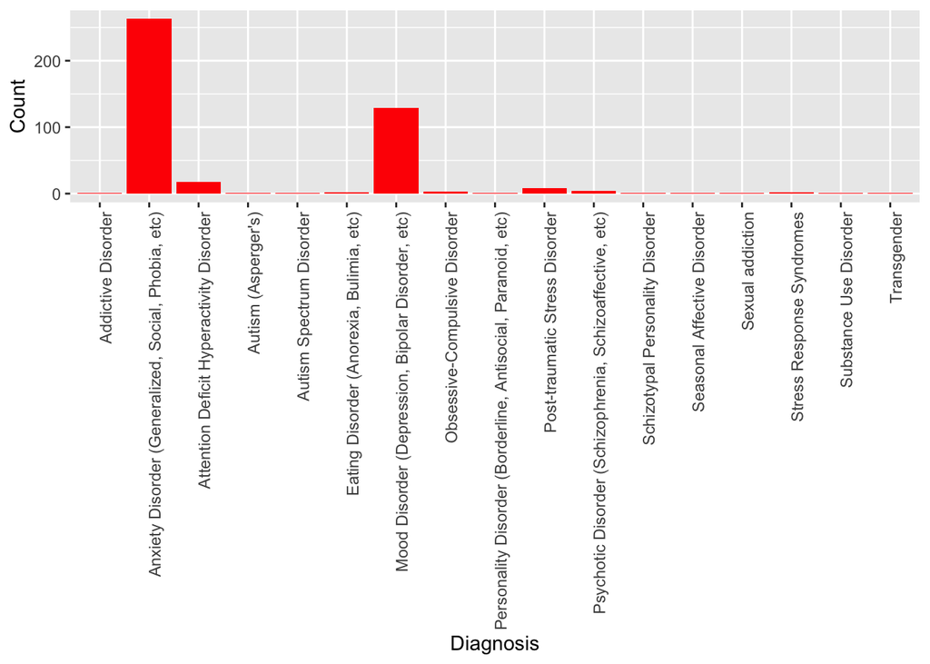

```r
library(ggplot2)
subcd1 <- subset(currentdiagnosis, !is.na(currentdiagnosis$curdiag_1))
ggplot(data = subcd1, aes(x = curdiag_1)) + geom_bar(fill = 'red') + labs(x = "Diagnosis", y = "Count") + theme(axis.text.x = element_text(angle = 90, hjust = 1))
```

Most common work position:

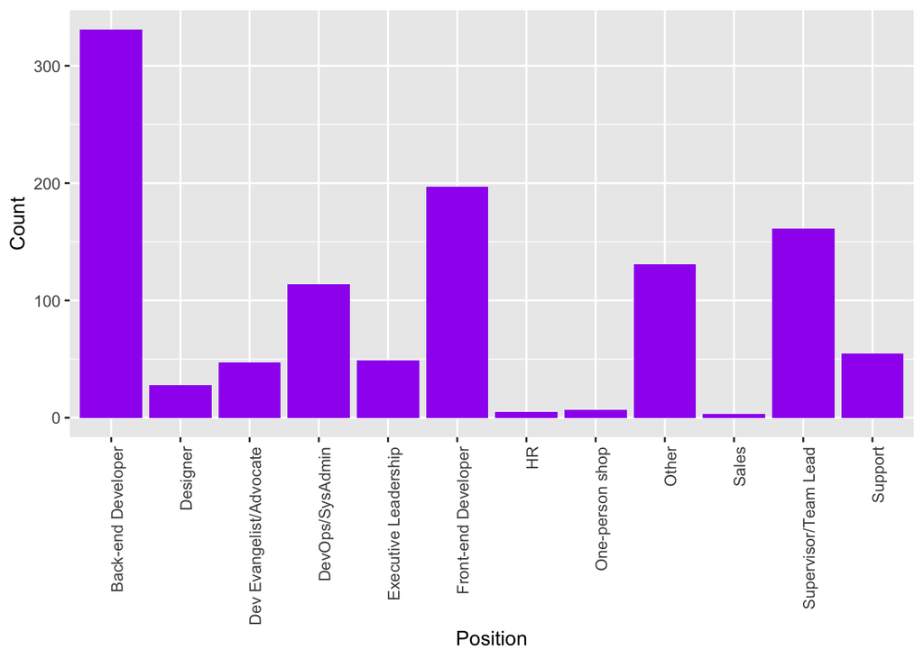

```r
wp1 <- subset(job, !is.na(job$wp_1))
ggplot(data = wp1, aes(x = wp_1)) + geom_bar(fill = 'purple') + labs(x = "Position", y = "Count") + theme(axis.text.x = element_text(angle = 90, hjust = 1))
```

The most common work positions are Back-end Developer and Front-end Developer. Most individuals stated they did at least one job, with individuals stating they did up to 10 different jobs.

Most common undiagnosed condition :

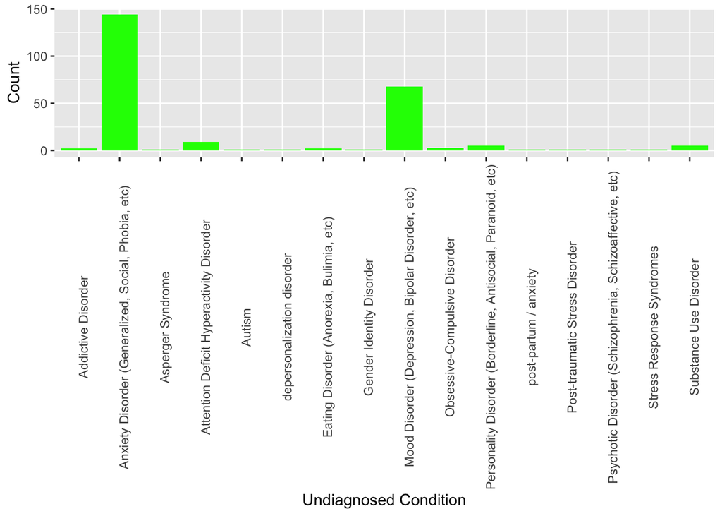

```r
undiag1 <- subset(undiagnosed, !is.na(undiagnosed$uc_1))
ggplot(data = undiag1, aes(x = uc_1)) + geom_bar(fill = 'green') + labs(x = "Undiagnosed Condition", y = "Count") + theme(axis.text.x = element_text(angle = 90))
```

Most individuals feel they have an undiagnosed Anxiety or Mood disorder.

Most common medically diagnosed condition:

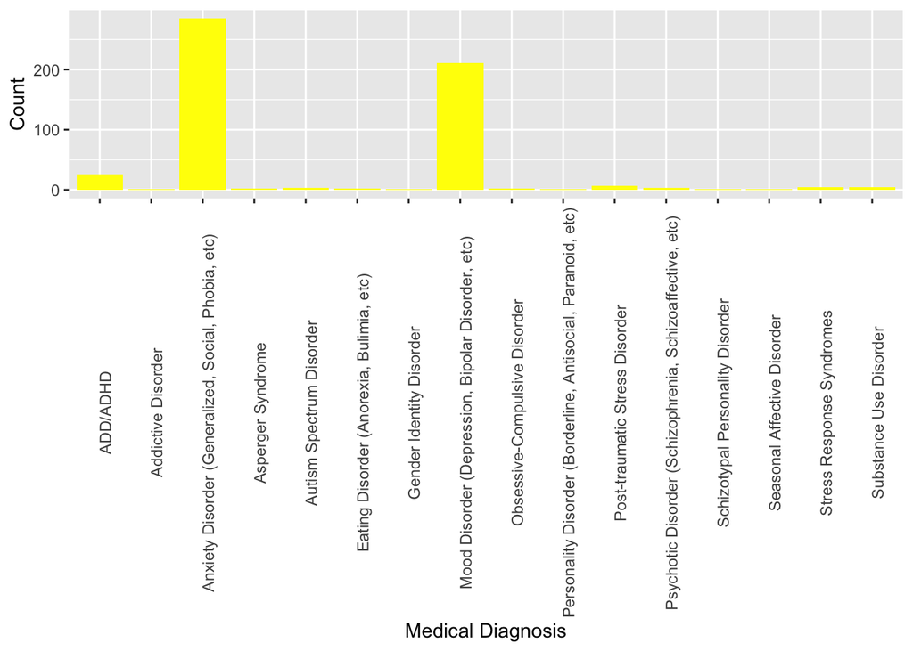

```r
meddiag1 <- subset(med_diagnosis, !is.na(med_diagnosis$cond_1))
ggplot(data = meddiag1, aes(x = cond_1)) + geom_bar(fill = 'yellow') + labs(x = "Medical Diagnosis", y = "Count") + theme(axis.text.x = element_text(angle = 90))
```

Most individuals have been medically diagnosed with an Anxiety or Mood disorder

Demographic Data:

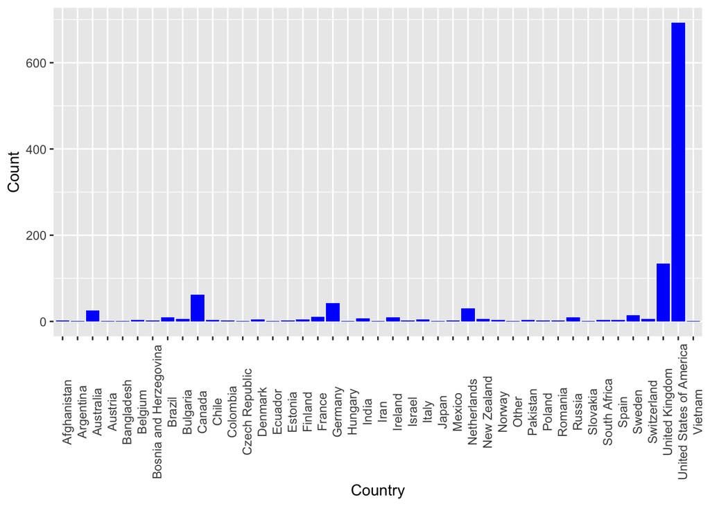

```r
ggplot(data = clean, aes(x = home_country)) + geom_bar(fill = 'blue') + labs(x = "Country", y = "Count") + theme(axis.text.x = element_text(angle = 90))
```

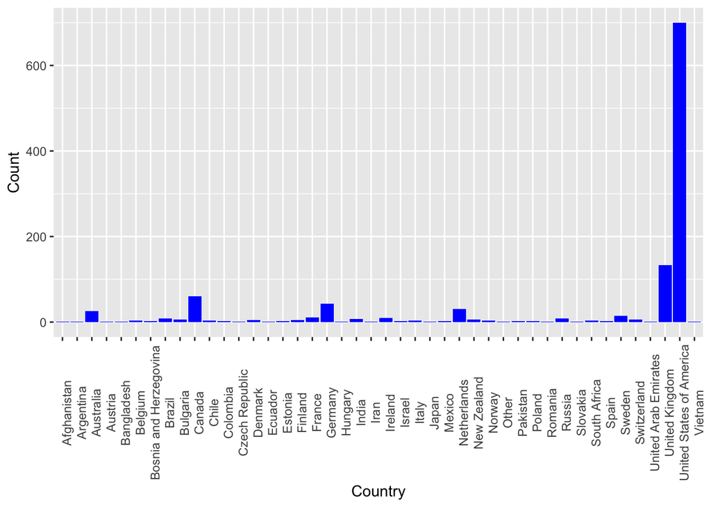

```r
ggplot(data = clean, aes(x = work_country)) + geom_bar(fill = 'blue') + labs(x = "Country", y = "Count") + theme(axis.text.x = element_text(angle = 90))
```

Most respondents are from the United States and work in the United States, with the UK coming in second.

Most respondents live and work in the same country.

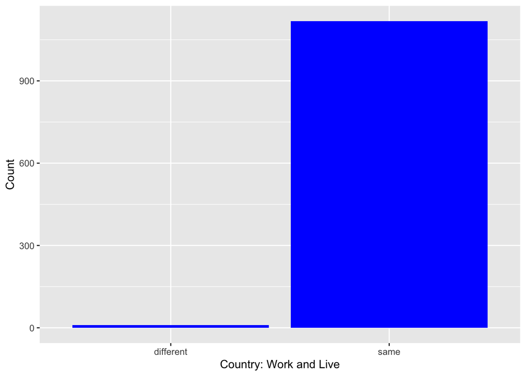

```r
ggplot(data = clean, aes(x = country)) + geom_bar(fill = 'blue') + labs(x = "Country: Work and Live", y = "Count")
```

Gender of Repondents

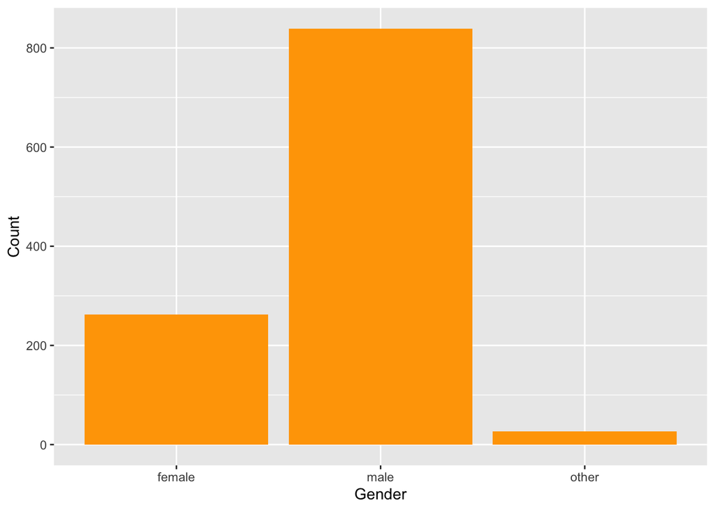

```r
ggplot(data = clean, aes(x = gender)) + geom_bar(fill = 'orange') + labs(x = "Gender", y = "Count")
```

Create new dataframe, removing attributes that have been moved to different dataframes

```r
analysis <- clean
analysis$ph_interview_why <- NULL
analysis$mh_interview_why <- NULL
analysis$current_diagnosis <- NULL
analysis$condition_undiagnosed <- NULL
analysis$condition_diagnosed_medpro <- NULL
analysis$work_position <- NULL
analysis$home_country <- NULL
analysis$home_state <- NULL
analysis$work_country <- NULL
analysis$work_state <- NULL
analysis$self_employed <- NULL
```

Clean up ‘analysis’

```r
analysis$tech_role <- factor(clean$tech_role, levels = c("O", "1"), labels = c("No", "Yes"))
analysis$sought_treatment <- factor(analysis$sought_treatment, levels = c("0", "1"), labels = c("No", "Yes"))
analysis$agegroup <- cut(clean$age, c(9, 19, 29, 39, 49, 59, 69, 79), labels = c("10-19","20-29", "30-39", "40-49", "50-59", "60-69", "70-79"))
summary(analysis$agegroup)
```

```
## 10-19 20-29 30-39 40-49 50-59 60-69 70-79
##     3   383   533   175    28     5     1
```

```r
analysis$age <- NULL
```

Dimensionality Reduction

```r
library(FSelector)
as.simple.formula(cutoff.biggest.diff(chi.squared(formula = diagnosed_medpro ~ ., data = analysis)), "diagnosed_medpro")
```

```
## diagnosed_medpro ~ mh_past + sought_treatment + mhi_work_treated_effectively +
##     mhi_work_not_treated_effectively + mh_current
## <environment: 0x7fe041e9d658>
```

```r
as.simple.formula(cutoff.biggest.diff(chi.squared(formula = sought_treatment ~ ., data = analysis)), "sought_treatment")
```

```
## sought_treatment ~ diagnosed_medpro + mh_past + mhi_work_treated_effectively +
##     mhi_work_not_treated_effectively + mh_current
## <environment: 0x7fe046d73668>
```

```r
as.simple.formula(cutoff.biggest.diff(information.gain(formula = diagnosed_medpro ~ ., data = analysis)), "diagnosed_medpro")
```

```
## diagnosed_medpro ~ mh_past + sought_treatment + mhi_work_treated_effectively +
##     mhi_work_not_treated_effectively + mh_current
## <environment: 0x7fe04427d828>
```

```r
as.simple.formula(cutoff.biggest.diff(information.gain(formula = sought_treatment ~ ., data = analysis)), "sought_treatment")
```

```
## sought_treatment ~ diagnosed_medpro + mh_past + mhi_work_treated_effectively +
##     mhi_work_not_treated_effectively + mh_current
## <environment: 0x7fe047ff8758>
```

```r
as.simple.formula(cfs(formula = diagnosed_medpro ~ ., data = analysis), "diagnosed_medpro")
```

```
## diagnosed_medpro ~ mh_past + mh_current + sought_treatment +
##     mhi_work_treated_effectively
## <environment: 0x7fe046820eb8>
```

```r
as.simple.formula(cfs(formula = sought_treatment ~ ., data = analysis), "sought_treatment")
```

```
## sought_treatment ~ mh_past + diagnosed_medpro + mhi_work_not_treated_effectively
## <environment: 0x7fe045201390>
```

```r
as.simple.formula(consistency(formula = diagnosed_medpro ~ ., data = analysis), "diagnosed_medpro")
```

```
## diagnosed_medpro ~ no_of_employees + mental_health_benefits +
##     options_mental_health + mh_leave_request + pe_mh_benefits +
##     team_neg_view_mh + mh_past + mh_current + sought_treatment +
##     mhi_work_treated_effectively
## <environment: 0x7fe0478a9600>
```

```r
as.simple.formula(consistency(formula = sought_treatment ~ ., data = analysis), "sought_treatment")
```

```
## sought_treatment ~ no_of_employees + mental_health_benefits +
##     options_mental_health + anonymity + mh_leave_request + pe_mh_discuss_coworker +
##     friends_family + mh_past + diagnosed_medpro + mhi_work_treated_effectively
## <environment: 0x7fe0487d3128>
```

The attributes selected by chi-squared were the same as those that were found using information gain. CFS had attributes that were found in chi-squared. Therefore, attributes found with chi-squared will be used to for model as these attributes were found using three different methods (shows strength).

Split data into train and test data

```r
set.seed(789)
analysis_train <- sample(nrow(analysis), floor(nrow(analysis)*0.7))
at_train <- analysis[analysis_train,]
at_test <- analysis[-analysis_train,]

class_error_calc <- function(actual, predicted) {
  mean(actual != predicted)
}
```

Logistic Regression Model for Diagnosed by a Medical Professional

```r
dm_lm <- glm(diagnosed_medpro ~ mh_past + sought_treatment + mhi_work_treated_effectively + mhi_work_not_treated_effectively + mh_current, family = "binomial", data = at_train)

summary(dm_lm)
```

```
##
## Call:
## glm(formula = diagnosed_medpro ~ mh_past + sought_treatment +
##     mhi_work_treated_effectively + mhi_work_not_treated_effectively +
##     mh_current, family = "binomial", data = at_train)
##
## Deviance Residuals:
##      Min        1Q    Median        3Q       Max
## -2.65807  -0.14439  -0.09318   0.26609   3.00098
##
## Coefficients:
##                                                      Estimate Std. Error
## (Intercept)                                          -1.72540    1.90445
## mh_pastNo                                            -0.87899    0.47971
## mh_pastYes                                            1.67988    0.35732
## sought_treatmentYes                                   2.61209    0.34698
## mhi_work_treated_effectivelyNot applicable to me     -1.16894    0.54387
## mhi_work_treated_effectivelyOften                     0.69146    0.79985
## mhi_work_treated_effectivelyRarely                    0.83156    0.45525
## mhi_work_treated_effectivelySometimes                 0.66039    0.44150
## mhi_work_not_treated_effectivelyNot applicable to me -1.68241    2.00105
## mhi_work_not_treated_effectivelyOften                -1.58884    1.94044
## mhi_work_not_treated_effectivelyRarely               -1.11654    1.98003
## mhi_work_not_treated_effectivelySometimes            -1.59746    1.92924
## mh_currentNo                                          0.01828    0.38652
## mh_currentYes                                         1.69371    0.34984
##                                                      z value Pr(>|z|)
## (Intercept)                                           -0.906   0.3649
## mh_pastNo                                             -1.832   0.0669 .
## mh_pastYes                                             4.701 2.58e-06 ***
## sought_treatmentYes                                    7.528 5.15e-14 ***
## mhi_work_treated_effectivelyNot applicable to me      -2.149   0.0316 *
## mhi_work_treated_effectivelyOften                      0.864   0.3873
## mhi_work_treated_effectivelyRarely                     1.827   0.0678 .
## mhi_work_treated_effectivelySometimes                  1.496   0.1347
## mhi_work_not_treated_effectivelyNot applicable to me  -0.841   0.4005
## mhi_work_not_treated_effectivelyOften                 -0.819   0.4129
## mhi_work_not_treated_effectivelyRarely                -0.564   0.5728
## mhi_work_not_treated_effectivelySometimes             -0.828   0.4077
## mh_currentNo                                           0.047   0.9623
## mh_currentYes                                          4.841 1.29e-06 ***
## ---
## Signif. codes:  0 '***' 0.001 '**' 0.01 '*' 0.05 '.' 0.1 ' ' 1
##
## (Dispersion parameter for binomial family taken to be 1)
##
##     Null deviance: 1093.23  on 788  degrees of freedom
## Residual deviance:  368.07  on 775  degrees of freedom
## AIC: 396.07
##
## Number of Fisher Scoring iterations: 7
```

```r
coef(dm_lm)
```

```
##                                          (Intercept)
##                                          -1.72539744
##                                            mh_pastNo
##                                          -0.87899334
##                                           mh_pastYes
##                                           1.67987904
##                                  sought_treatmentYes
##                                           2.61208699
##     mhi_work_treated_effectivelyNot applicable to me
##                                          -1.16893817
##                    mhi_work_treated_effectivelyOften
##                                           0.69145959
##                   mhi_work_treated_effectivelyRarely
##                                           0.83155551
##                mhi_work_treated_effectivelySometimes
##                                           0.66038848
## mhi_work_not_treated_effectivelyNot applicable to me
##                                          -1.68240842
##                mhi_work_not_treated_effectivelyOften
##                                          -1.58883601
##               mhi_work_not_treated_effectivelyRarely
##                                          -1.11653751
##            mhi_work_not_treated_effectivelySometimes
##                                          -1.59745724
##                                         mh_currentNo
##                                           0.01827539
##                                        mh_currentYes
##                                           1.69371243
```

```r
#betas for the equations:
head(predict(dm_lm))
```

```
##       1036        996        839        783       1267        204
## -0.1998268 -5.4374620 -5.4374620  2.6628238  2.6714450  3.3232123
```

```r
#probabilities:
head(predict(dm_lm, type = "response"))
```

```
##        1036         996         839         783        1267         204
## 0.450208869 0.004331666 0.004331666 0.934796992 0.935320504 0.965216600
```

```r
#classifications:
dm_lm_predict <- ifelse(predict(dm_lm, newdata = at_test, type = "link") > 0, "Yes", "No")
table(dm_lm_predict, at_test$diagnosed_medpro)
```

```
##
## dm_lm_predict  No Yes
##           No  150  17
##           Yes  14 158
```

```r
class_error_calc(actual = at_test$diagnosed_medpro, predicted = dm_lm_predict)
```

```
## [1] 0.09144543
```

Logistic Regression Model for whether or not an individual sought treatment for a mental health condition

```r
st_lm <- glm(sought_treatment ~ diagnosed_medpro + mh_past + mhi_work_treated_effectively + mhi_work_not_treated_effectively + mh_current, family = "binomial", data = at_train)

summary(st_lm)
```

```
##
## Call:
## glm(formula = sought_treatment ~ diagnosed_medpro + mh_past +
##     mhi_work_treated_effectively + mhi_work_not_treated_effectively +
##     mh_current, family = "binomial", data = at_train)
##
## Deviance Residuals:
##     Min       1Q   Median       3Q      Max
## -2.8872  -0.3879   0.1630   0.3441   2.2912
##
## Coefficients:
##                                                      Estimate Std. Error
## (Intercept)                                          -16.5139   578.5273
## diagnosed_medproYes                                    2.5827     0.3509
## mh_pastNo                                             -0.8286     0.3552
## mh_pastYes                                             0.6426     0.3668
## mhi_work_treated_effectivelyNot applicable to me      -1.3552     0.5242
## mhi_work_treated_effectivelyOften                     -1.3676     0.7347
## mhi_work_treated_effectivelyRarely                     0.1622     0.5059
## mhi_work_treated_effectivelySometimes                 -0.4745     0.4830
## mhi_work_not_treated_effectivelyNot applicable to me  16.5206   578.5276
## mhi_work_not_treated_effectivelyOften                 17.9268   578.5274
## mhi_work_not_treated_effectivelyRarely                16.0179   578.5275
## mhi_work_not_treated_effectivelySometimes             16.5661   578.5274
## mh_currentNo                                          -0.3725     0.3593
## mh_currentYes                                         -0.4858     0.3879
##                                                      z value Pr(>|z|)
## (Intercept)                                           -0.029  0.97723
## diagnosed_medproYes                                    7.359 1.85e-13 ***
## mh_pastNo                                             -2.333  0.01966 *
## mh_pastYes                                             1.752  0.07982 .
## mhi_work_treated_effectivelyNot applicable to me      -2.585  0.00973 **
## mhi_work_treated_effectivelyOften                     -1.862  0.06267 .
## mhi_work_treated_effectivelyRarely                     0.321  0.74850
## mhi_work_treated_effectivelySometimes                 -0.982  0.32597
## mhi_work_not_treated_effectivelyNot applicable to me   0.029  0.97722
## mhi_work_not_treated_effectivelyOften                  0.031  0.97528
## mhi_work_not_treated_effectivelyRarely                 0.028  0.97791
## mhi_work_not_treated_effectivelySometimes              0.029  0.97716
## mh_currentNo                                          -1.037  0.29980
## mh_currentYes                                         -1.252  0.21039
## ---
## Signif. codes:  0 '***' 0.001 '**' 0.01 '*' 0.05 '.' 0.1 ' ' 1
##
## (Dispersion parameter for binomial family taken to be 1)
##
##     Null deviance: 1075.77  on 788  degrees of freedom
## Residual deviance:  469.03  on 775  degrees of freedom
## AIC: 497.03
##
## Number of Fisher Scoring iterations: 14
```

```r
coef(st_lm)
```

```
##                                          (Intercept)
##                                          -16.5138518
##                                  diagnosed_medproYes
##                                            2.5826725
##                                            mh_pastNo
##                                           -0.8285949
##                                           mh_pastYes
##                                            0.6425707
##     mhi_work_treated_effectivelyNot applicable to me
##                                           -1.3551566
##                    mhi_work_treated_effectivelyOften
##                                           -1.3676155
##                   mhi_work_treated_effectivelyRarely
##                                            0.1622000
##                mhi_work_treated_effectivelySometimes
##                                           -0.4744530
## mhi_work_not_treated_effectivelyNot applicable to me
##                                           16.5205913
##                mhi_work_not_treated_effectivelyOften
##                                           17.9268166
##               mhi_work_not_treated_effectivelyRarely
##                                           16.0179364
##            mhi_work_not_treated_effectivelySometimes
##                                           16.5661490
##                                         mh_currentNo
##                                           -0.3725128
##                                        mh_currentYes
##                                           -0.4858306
```

```r
#betas for the equations:
head(predict(st_lm))
```

```
##       1036        996        839        783       1267        204
## -0.6602887 -2.5495247 -2.5495247  2.7917098  4.1523773  2.3172568
```

```r
#probabilities
head(predict(st_lm, type = "response"))
```

```
##       1036        996        839        783       1267        204
## 0.34067476 0.07245842 0.07245842 0.94222619 0.98451652 0.91029619
```

```r
#classifications
st_lm_predict <- ifelse(predict(st_lm, newdata = at_test, type = "link") > 0, "Yes", "No")
table(st_lm_predict, at_test$sought_treatment)
```

```
##
## st_lm_predict  No Yes
##           No  123  22
##           Yes  23 171
```

```r
class_error_calc(actual = at_test$sought_treatment, predicted = st_lm_predict)
```

```
## [1] 0.1327434
```

Create matrix for ANN diganosed by medical professional model with chi-square attributes

```r
library(neuralnet)
mm_dm <- model.matrix(~diagnosed_medpro + mh_past + sought_treatment + mhi_work_treated_effectively + mhi_work_not_treated_effectively + mh_current, data = analysis)
head(mm_dm)
```

```
##   (Intercept) diagnosed_medproYes mh_pastNo mh_pastYes sought_treatmentYes
## 1           1                   1         0          1                   0
## 2           1                   1         0          1                   1
## 3           1                   0         0          0                   1
## 5           1                   1         0          1                   1
## 6           1                   0         1          0                   1
## 7           1                   0         1          0                   0
##   mhi_work_treated_effectivelyNot applicable to me
## 1                                                1
## 2                                                0
## 3                                                1
## 5                                                0
## 6                                                1
## 7                                                1
##   mhi_work_treated_effectivelyOften mhi_work_treated_effectivelyRarely
```

[output cut: 34 more lines]

Create random sample and split matrix data into train and test data

```r
set.seed(789)
index_analysis_dm <- sample(nrow(mm_dm), floor(nrow(mm_dm)*0.7))
at_train_dm <- mm_dm[index_analysis_dm,]
at_test_dm <- as.data.frame(mm_dm[-index_analysis_dm,])
```

Artifical Neural Network (ANN) Model for whether or not an individual has been diagnosed with a mental health condition by a medical professional

```r
nn_dm <- neuralnet(diagnosed_medproYes ~ mh_pastNo + mh_pastYes + sought_treatmentYes + mhi_work_treated_effectivelyOften + mhi_work_treated_effectivelyRarely + mhi_work_treated_effectivelySometimes + mhi_work_not_treated_effectivelyOften + mhi_work_not_treated_effectivelyRarely + mhi_work_not_treated_effectivelySometimes + mh_currentNo + mh_currentYes, data = at_train_dm)
plot(nn_dm)

at_test_dm_subset <- subset(at_test_dm, select = c("mh_pastNo", "mh_pastYes", "sought_treatmentYes", "mhi_work_treated_effectivelyOften", "mhi_work_treated_effectivelyRarely", "mhi_work_treated_effectivelySometimes", "mhi_work_not_treated_effectivelyOften", "mhi_work_not_treated_effectivelyRarely", "mhi_work_not_treated_effectivelySometimes", "mh_currentNo", "mh_currentYes"))
nn_dm_predict <- compute(nn_dm, at_test_dm_subset)
nn_dm_results <- data.frame(actual = at_test_dm$diagnosed_medproYes, prediction = nn_dm_predict$net.result)
head(nn_dm_results)
```

```
##    actual prediction
## 14      0 0.01266879
## 15      1 0.94574462
## 17      1 0.94451977
## 18      0 0.01025492
## 26      0 0.01025492
## 29      0 0.86069079
```

Create matrix for ANN sought treatment model with chi-square attributes

```r
mm_st <- model.matrix(~sought_treatment + diagnosed_medpro + mh_past + mhi_work_treated_effectively + mhi_work_not_treated_effectively + mh_current, data = analysis)
head(mm_st)
```

```
##   (Intercept) sought_treatmentYes diagnosed_medproYes mh_pastNo mh_pastYes
## 1           1                   0                   1         0          1
## 2           1                   1                   1         0          1
## 3           1                   1                   0         0          0
## 5           1                   1                   1         0          1
## 6           1                   1                   0         1          0
## 7           1                   0                   0         1          0
##   mhi_work_treated_effectivelyNot applicable to me
## 1                                                1
## 2                                                0
## 3                                                1
## 5                                                0
## 6                                                1
## 7                                                1
##   mhi_work_treated_effectivelyOften mhi_work_treated_effectivelyRarely
```

[output cut: 34 more lines]

Create random sample and split matrix data into train and test

```r
index_analysis_st <- sample(nrow(mm_st), floor(nrow(mm_st)*0.7))
at_train_st <- mm_st[index_analysis_st,]
at_test_st <- as.data.frame(mm_st[-index_analysis_st,])
```

Artifical Neural Network (ANN) Model for whether or not an individual sought treatment for a mental health condition

```r
nn_st <- neuralnet(sought_treatmentYes ~ diagnosed_medproYes + mh_pastNo + mh_pastYes + mhi_work_treated_effectivelyOften + mhi_work_treated_effectivelyRarely + mhi_work_treated_effectivelySometimes + mhi_work_not_treated_effectivelyOften + mhi_work_not_treated_effectivelyRarely + mhi_work_not_treated_effectivelySometimes + mh_currentNo + mh_currentYes, data = at_train_st)
plot(nn_st)

at_test_st_subset <- subset(at_test_st, select = c("diagnosed_medproYes", "mh_pastNo", "mh_pastYes", "mhi_work_treated_effectivelyOften", "mhi_work_treated_effectivelyRarely", "mhi_work_treated_effectivelySometimes", "mhi_work_not_treated_effectivelyOften", "mhi_work_not_treated_effectivelyRarely", "mhi_work_not_treated_effectivelySometimes", "mh_currentNo", "mh_currentYes"))
nn_st_predict <- compute(nn_st, at_test_st_subset)
nn_st_results <- data.frame(actual = at_test_st$sought_treatmentYes, prediction = nn_st_predict$net.result)
head(nn_st_results)
```

```
##    actual prediction
## 1       0  0.9558490
## 2       1  0.9584704
## 6       1  0.1188453
## 9       1  0.9604902
## 11      1  0.9577751
## 12      1  0.9449429
```

Decision Tree for whether or not an individual has been diagnosed by a medical professional

```r
library(partykit)
ctree_dm <- ctree(diagnosed_medpro ~ ., data = at_train)
print(ctree_dm)
```

```
##
## Model formula:
## diagnosed_medpro ~ no_of_employees + tech_company + tech_role +
##     mental_health_benefits + options_mental_health + wellness_campaign +
##     mh_resources + anonymity + mh_leave_request + mh_discuss_neg_cons +
##     ph_discuss_neg_cons + mh_discuss_coworker + mh_discuss_supervisor +
##     mh_serious_ph + observe_negcons_mh + previous_employer +
##     pe_mh_benefits + pe_mh_options + pe_wellness_campaign + pe_mh_resources +
##     pe_anonymity + pe_mh_discuss_negcons + pe_ph_discuss_negcons +
##     pe_mh_discuss_coworker + pe_mh_discuss_supervisor + pe_mh_serious_ph +
##     pe_observe_negcons_mh + ph_interview + mh_interview + id_mh_hurt_career +
##     team_neg_view_mh + friends_family + unsupportive_response_mh +
##     obs_impact + mh_family_history + mh_past + mh_current + sought_treatment +
##     mhi_work_treated_effectively + mhi_work_not_treated_effectively +
##     gender + work_remotely + country + state + agegroup
##
## Fitted party:
## [1] root
## |   [2] mh_past in Maybe, No
## |   |   [3] mh_current in Maybe, No
## |   |   |   [4] mhi_work_treated_effectively in Never, Not applicable to me, Often: No (n = 295, err = 0.7%)
## |   |   |   [5] mhi_work_treated_effectively in Rarely, Sometimes
## |   |   |   |   [6] sought_treatment in No: No (n = 28, err = 3.6%)
## |   |   |   |   [7] sought_treatment in Yes
## |   |   |   |   |   [8] mh_current in Maybe: Yes (n = 23, err = 34.8%)
## |   |   |   |   |   [9] mh_current in No: No (n = 9, err = 0.0%)
## |   |   [10] mh_current in Yes: Yes (n = 33, err = 27.3%)
## |   [11] mh_past in Yes
## |   |   [12] sought_treatment in No: No (n = 42, err = 38.1%)
## |   |   [13] sought_treatment in Yes
## |   |   |   [14] mh_current in Maybe, No: Yes (n = 106, err = 17.9%)
## |   |   |   [15] mh_current in Yes
## |   |   |   |   [16] mhi_work_treated_effectively in Never, Often, Rarely, Sometimes: Yes (n = 244, err = 4.5%)
## |   |   |   |   [17] mhi_work_treated_effectively in Not applicable to me: Yes (n = 9, err = 33.3%)
##
## Number of inner nodes:    8
## Number of terminal nodes: 9
```

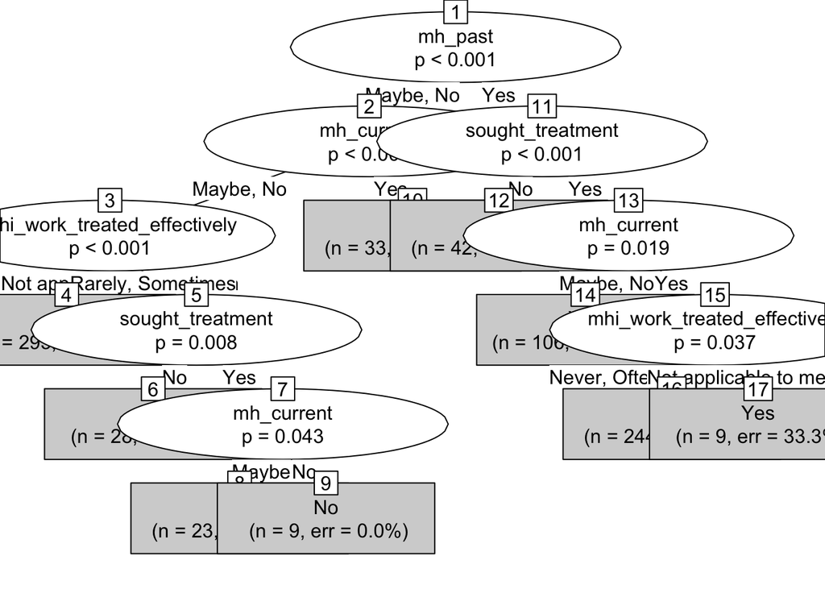

```r
plot(ctree_dm, type = "simple")
```

```r
ctree_dm_predict <- predict(ctree_dm, at_test)
table(ctree_dm_predict, at_test$diagnosed_medpro)
```

```
##
## ctree_dm_predict  No Yes
##              No  145  13
##              Yes  19 162
```

Decision Tree for whether or not an individual sought treatment for a mental health condtion

```r
ctree_st <- ctree(sought_treatment ~ ., data = at_train)
print(ctree_st)
```

[output not shown]

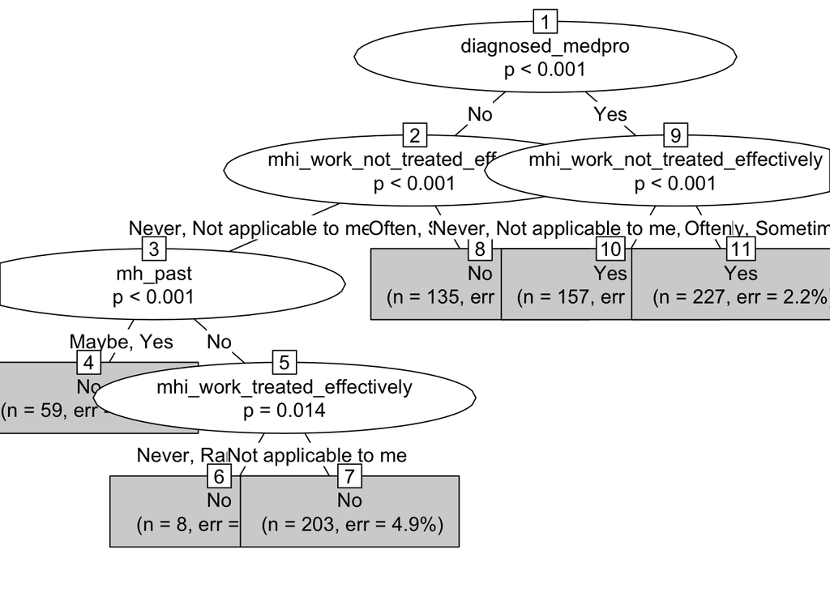

```r
plot(ctree_st, type = "simple")
```

```r
ctree_st_predict <- predict(ctree_st, at_test)
table(ctree_st_predict, at_test$sought_treatment)
```

```
##
## ctree_st_predict  No Yes
##              No  135  29
##              Yes  11 164
```

EVALUATION OF MODELS

Confusion Matrices:

```r
library(caret)
dm_lm_predict <- as.factor(dm_lm_predict)
st_lm_predict <- as.factor(st_lm_predict)

confusionMatrix(data = dm_lm_predict, reference = at_test$diagnosed_medpro, positive = c("Yes"))
```

```
## Confusion Matrix and Statistics
##
##           Reference
## Prediction  No Yes
##        No  150  17
##        Yes  14 158
##
##                Accuracy : 0.9086
##                  95% CI : (0.8727, 0.937)
##     No Information Rate : 0.5162
##     P-Value [Acc > NIR] : <2e-16
##
##                   Kappa : 0.817
##
##  Mcnemar's Test P-Value : 0.7194
##
##             Sensitivity : 0.9029
##             Specificity : 0.9146
##          Pos Pred Value : 0.9186
##          Neg Pred Value : 0.8982
##              Prevalence : 0.5162
##          Detection Rate : 0.4661
##    Detection Prevalence : 0.5074
##       Balanced Accuracy : 0.9087
##
##        'Positive' Class : Yes
##
```

```r
confusionMatrix(data = st_lm_predict, reference = at_test$sought_treatment, positive = c("Yes"))
```

```
## Confusion Matrix and Statistics
##
##           Reference
## Prediction  No Yes
##        No  123  22
##        Yes  23 171
##
##                Accuracy : 0.8673
##                  95% CI : (0.8264, 0.9015)
##     No Information Rate : 0.5693
##     P-Value [Acc > NIR] : <2e-16
##
##                   Kappa : 0.7291
##
##  Mcnemar's Test P-Value : 1
##
##             Sensitivity : 0.8860
##             Specificity : 0.8425
##          Pos Pred Value : 0.8814
##          Neg Pred Value : 0.8483
##              Prevalence : 0.5693
##          Detection Rate : 0.5044
##    Detection Prevalence : 0.5723
##       Balanced Accuracy : 0.8642
##
##        'Positive' Class : Yes
##
```

```r
confusionMatrix(data = ctree_dm_predict, reference = at_test$diagnosed_medpro, positive = c("Yes"))
```

```
## Confusion Matrix and Statistics
##
##           Reference
## Prediction  No Yes
##        No  145  13
##        Yes  19 162
##
##                Accuracy : 0.9056
##                  95% CI : (0.8694, 0.9345)
##     No Information Rate : 0.5162
##     P-Value [Acc > NIR] : <2e-16
##
##                   Kappa : 0.8108
##
##  Mcnemar's Test P-Value : 0.3768
##
##             Sensitivity : 0.9257
##             Specificity : 0.8841
##          Pos Pred Value : 0.8950
##          Neg Pred Value : 0.9177
##              Prevalence : 0.5162
##          Detection Rate : 0.4779
##    Detection Prevalence : 0.5339
##       Balanced Accuracy : 0.9049
##
##        'Positive' Class : Yes
##
```

```r
confusionMatrix(data = ctree_st_predict, reference = at_test$sought_treatment, positive = c("Yes"))
```

```
## Confusion Matrix and Statistics
##
##           Reference
## Prediction  No Yes
##        No  135  29
##        Yes  11 164
##
##                Accuracy : 0.882
##                  95% CI : (0.8428, 0.9144)
##     No Information Rate : 0.5693
##     P-Value [Acc > NIR] : < 2e-16
##
##                   Kappa : 0.7629
##
##  Mcnemar's Test P-Value : 0.00719
##
##             Sensitivity : 0.8497
##             Specificity : 0.9247
##          Pos Pred Value : 0.9371
##          Neg Pred Value : 0.8232
##              Prevalence : 0.5693
##          Detection Rate : 0.4838
##    Detection Prevalence : 0.5162
##       Balanced Accuracy : 0.8872
##
##        'Positive' Class : Yes
##
```

```r
#confusion matrix for ANN diagnosed medpro
nn_dm_results_round<- as.data.frame(sapply(nn_dm_results,round,digits=0))
table(nn_dm_results_round$actual, nn_dm_results_round$prediction)
```

```
##
##       0   1
##   0 146  18
##   1  13 162
```

```r
#confusion matrix for ANN sought treatment
nn_st_results_round<- as.data.frame(sapply(nn_st_results,round,digits=0))
table(nn_st_results_round$actual, nn_st_results_round$prediction)
```

```
##
##       0   1
##   0 117  26
##   1  26 170
```

Brier Score

```r
library(DescTools)
BrierScore(dm_lm)
```

```
## [1] 0.06880312
```

```r
BrierScore(st_lm)
```

```
## [1] 0.08916919
```

```r
ctree_dm_predict <- as.numeric(factor(ctree_dm_predict, levels = c("No", "Yes"), labels = c(0 ,1)))
at_test$diagnosed_medpro <- as.integer(at_test$diagnosed_medpro)
BrierScore(ctree_dm_predict, at_test$diagnosed_medpro)
```

```
## [1] -0.9734513
```

```r
ctree_st_predict <- as.numeric(factor(ctree_st_predict, levels = c("No", "Yes"), labels = c(0,1)))
at_test$sought_treatment <- as.numeric(at_test$sought_treatment)
BrierScore(ctree_st_predict, at_test$sought_treatment)
```

```
## [1] -0.9144543
```

```r
BrierScore(nn_dm_results_round$prediction, nn_dm_results_round$actual)
```

```
## [1] 0.09144543
```

```r
BrierScore(nn_st_results_round$prediction, nn_st_results_round$actual)
```

```
## [1] 0.1533923
```